# Project_Report

**Bike Share Project: Final Report**

A report for the bikeshare data modeling project.

by Aditi Gala

[figure not shown]

### Objective & Summary

The main objective of this mini project was to look at bike share data and create models that **predict the daily count and hourly count of bike rentals**.

After data wrangling and pre-processing, some exploratory data analysis (EDA) was performed to see which continous features were most correlated with the count of bike rentals. The EDA showed that not all features had a linear relationship with the total rental count, and therefore a more complex model would be better for predicting daily & hourly bike rentals. The two deep neural networks developed in this project perform sufficiently well on train and test data, therefore we have reason to believe they are good models for predicting daily and hourly bike rentals.

### Data Wrangling

This section refers to the work in "1_DataWrangling.ipynb". Data Wrangling involved the following steps (for both the daily and houry datasets):

1. Loading the .csv file into a dataframe
2. Checking for NA values & replacing with averages (there were no NAs)
3. One-Hot encoding for the weather column which has multiple categories
4. Exracting Year, Month, and Day from the date column "dteday"
5. Save the new dataframe as .csv files in the "Data" folder

The final "daily_clean.csv" dataset has 731 rows and 21 columns. The final "hourly_clean.csv" dataset has 17379 rows and 23 columns.

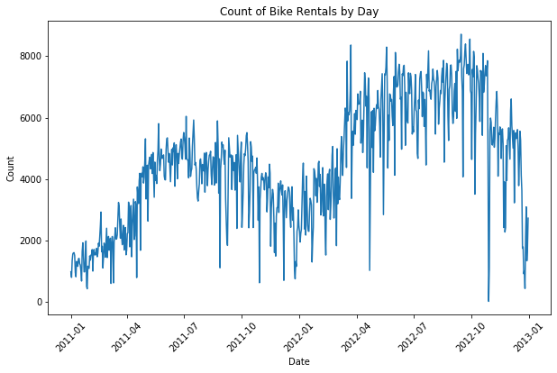

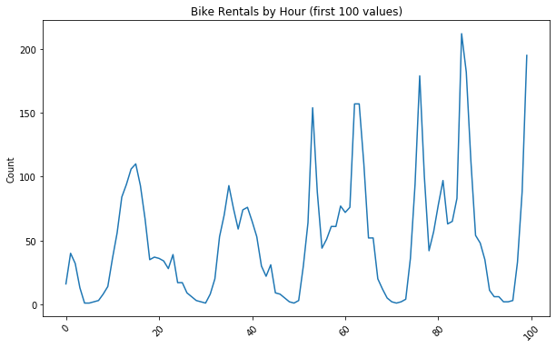

```python
# Import Libraries
import numpy as np
import pandas as pd
import warnings
warnings.filterwarnings("ignore")
from matplotlib import pyplot as plt
%matplotlib inline

# Load the daily csv data
file_path = "/Users/aditigala/Documents/Pacific/Software_Methods/Bikeshare/Data/daily.csv"
daily = pd.read_csv(file_path)
plt.figure(figsize = (10,6))
date_objects = [pd.datetime.strptime(date, '%Y-%m-%d').date() for date in daily["dteday"]]
plt.plot(date_objects, daily["cnt"])
plt.xticks(rotation = 45)
plt.xlabel('Date')
plt.ylabel('Count')
plt.title("Count of Bike Rentals by Day")
plt.show()

# Load the hourly csv data
file_path = "/Users/aditigala/Documents/Pacific/Software_Methods/Bikeshare/Data/hourly.csv"
hourly = pd.read_csv(file_path)

# Plot of bike rentals over time
plt.figure(figsize = (10,6))
date_objects = [pd.datetime.strptime(date, '%Y-%m-%d').date() for date in hourly["dteday"][:100]]
x_labels = str(hourly["dteday"])+str(hourly["hr"])
plt.plot(hourly["cnt"][:100])
plt.xticks(rotation = 45)
plt.ylabel('Index')
plt.ylabel('Count')
plt.title("Bike Rentals by Hour (first 100 values)")
plt.show()
```

### Exploratory Data Analysis (EDA) Results

This section refers to the work in "2_EDA.ipynb". The EDA involved correlation analysis followed by multi-variate regression analysis, but only for the continuous features in the two datasets. These features are: "Year", "Month", "Day", "temp", "atemp", "hum", "windspeed".

The correlations showed that the two features with the stronger correlation with count is temperature (temp/atemp), and Year. Windspeed and Month have a weaker correlation with daily count. We also see a weaker correlations in the hourly data as compared to the daily data.

The **daily** full model linear regression model (where all the continuous features were selected) had an adjust R-squared of 0.750. For comparison, a simpler 2 feature model using only "atemp" and "Year" had an adjusted R-squared of 0.687.

The **hourly** full model linear regression model (where all the continuous features were selected) had an adjust R-squared of 0.306. This relatively low value shows us that a linear model may not be a good fit for the hourly data.

### Modeling

This section refers to the work in "3_Modeling.ipynb". Following the results from the exploratory data analysis, it was determined that a complex, non-linear model such as a Deep Neural Network may be required to predict bike rentals.

For the daily data: The deep Neural Network has the following structure:

- The first hiddel layer has 6 neurons, with a ReLu activation function
- The second hidden layer has 8 neurons, with a "ReLu" activation function
- Each hidden layer is followed by a drop out layer (0.1) to introduce some randomness into the model training and avoid over-fitting
- The output layer has one neuron and linear activation function.

For the hourly data: Because the hourly dataset is much larger, we could afford to create a slightly more complex model than for the daily data. The deep Neural Network for the hourly data has the following structure:

- The first hiddel layer has 12 neurons, with a ReLu activation function
- The second hidden layer has 12 neurons, with a "ReLu" activation function
- Each hidden layer is followed by a drop out layer (0.1) to introduce some randomness into the model training and avoid over-fitting
- The output layer has one neuron and linear activation function.

The predictions for the test data are exported to a .csv file, so they can be accessed for the plot below.

### Analysis & Evaluation

This section also refers to the work done in "3_Modeling.ipynb". The test data and test predictions from both our models were saved to two .csv files under the "Data" directory. This data is plotted below (same as the plots in 3_Modeling). The first plot shows all the daily test predictions vs actual values. The second plot below shows the first 100 test predictions vs actual values for hourly data.

MAE (Mean Absolute Error) is used to judge the models. The **MAE for the daily model** on test data set after **40 epochs of training** is **0.087**. The **MAE for the hourly model** on test data set after **40 epochs of training** is **0.072**. These low error values tell us that our model is predicting really well!

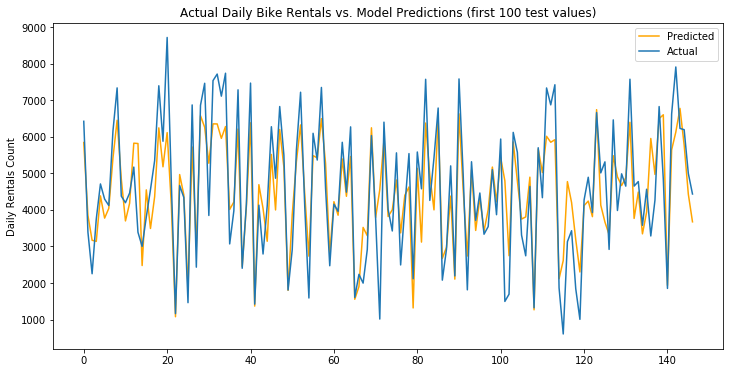

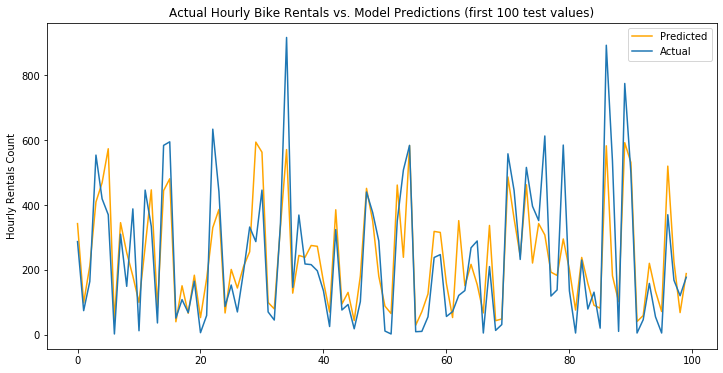

```python
# Import test predictions for daily model
file_path = "/Users/aditigala/Documents/Pacific/Software_Methods/Bikeshare/Data/daily_preds.csv"
daily_preds = pd.read_csv(file_path, index_col = 0)
# Plot
plt.figure(figsize = (12,6))
plt.plot(daily_preds["0.1"], label='Predicted', color = 'orange')
plt.plot(daily_preds["0"], label = 'Actual')
plt.ylabel("Daily Rentals Count")
plt.title("Actual Daily Bike Rentals vs. Model Predictions (first 100 test values)")
plt.legend()
plt.show()

# Import test predictions for hourly model
file_path = "/Users/aditigala/Documents/Pacific/Software_Methods/Bikeshare/Data/hourly_preds.csv"
hourly_preds = pd.read_csv(file_path, index_col = 0)
# Plot
plt.figure(figsize = (12,6))
plt.plot(hourly_preds["0.1"], label='Predicted', color = 'orange')
plt.plot(hourly_preds["0"], label='Actual')
plt.ylabel("Hourly Rentals Count")
plt.legend()
plt.title("Actual Hourly Bike Rentals vs. Model Predictions (first 100 test values)")

plt.show()
```

```python
%%javascript
$.getScript('https://kmahelona.github.io/ipython_notebook_goodies/ipython_notebook_toc.js')
```